# Packet 10 - Linear Models

Todd CadwalladerOlsker

*Last updated:* 2022-05-03

# Linear Regression

**Lightly read pages 305-311 of OpenIntro Statistics.**

## First Steps

After loading the `openintro` library, let’s examine the `elmhurst` data set. Use `View(elmhurst)` to see the data, and `help("elmhurst")` to get more information on the variables, how the data was collected, etc.

We might expect a relationship between family income and the amount of gift aid (scholarships, grants, and the like) offered. Let’s find out:

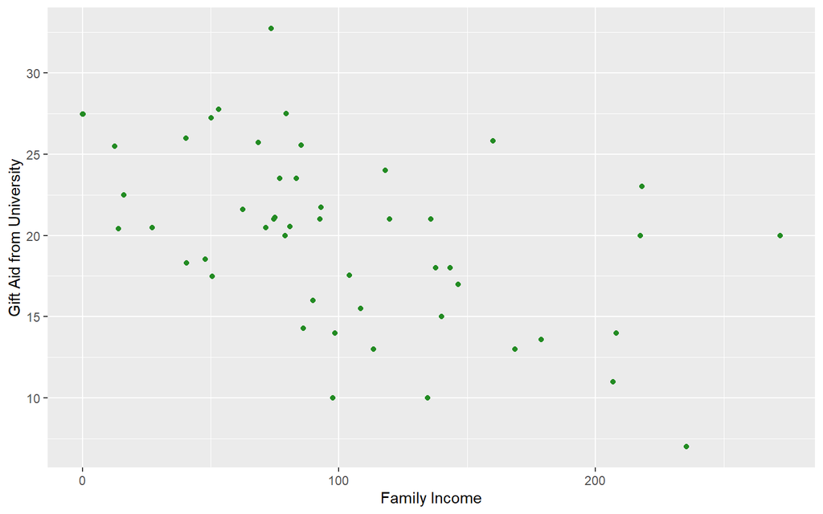

```r
elmhurst %>% ggplot(aes(x = family_income, y = gift_aid)) +
  geom_point(color='forestgreen') +
  labs(x = "Family Income",
       y = "Gift Aid from University")
```

```r
elm_model <- elmhurst %>%
  lm(gift_aid ~ family_income, data = .)
summary(elm_model)
```

```
##
## Call:
## lm(formula = gift_aid ~ family_income, data = .)
##
## Residuals:
##      Min       1Q   Median       3Q      Max
## -10.1128  -3.6234  -0.2161   3.1587  11.5707
##
## Coefficients:
##               Estimate Std. Error t value             Pr(>|t|)
## (Intercept)   24.31933    1.29145  18.831 < 0.0000000000000002 ***
## family_income -0.04307    0.01081  -3.985             0.000229 ***
## ---
## Signif. codes:  0 '***' 0.001 '**' 0.01 '*' 0.05 '.' 0.1 ' ' 1
##
## Residual standard error: 4.783 on 48 degrees of freedom
## Multiple R-squared:  0.2486, Adjusted R-squared:  0.2329
## F-statistic: 15.88 on 1 and 48 DF,  p-value: 0.0002289
```

```r
R <- elmhurst %>% summarize(cor(gift_aid,family_income))
R
```

```
## # A tibble: 1 × 1
##   `cor(gift_aid, family_income)`
##                            <dbl>
## 1                         -0.499
```

```r
R_squared <- elmhurst %>% summarize(cor(gift_aid,family_income)^2)
R_squared
```

```
## # A tibble: 1 × 1
##   `cor(gift_aid, family_income)^2`
##                              <dbl>
## 1                            0.249
```

Finally, we can plot the least squares regression line along with our data:

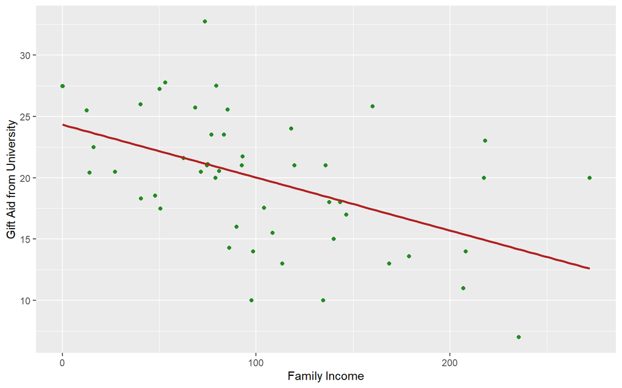

```r
elmhurst %>%  ggplot(aes(x = family_income, y = gift_aid)) +
  geom_point(color='forestgreen') +
  labs(x = "Family Income",
       y = "Gift Aid from University") +
  geom_smooth(color='firebrick', method=lm, se=FALSE)
```

Before continuing, draw 2 more more scatter plots: First, plot `family_income` on the x-axis and `price_paid` on the y-axis, then `gift_aid` on the x-axis and `price_paid` on the y-axis. For each of these, plot the linear regression line, and find the $R$ and $R^2$ values. What do you notice/wonder?

## Confidence Intervals and Hypothesis Tests for slope and correlation

Our old friend, the `infer` package, can use the bootstrap to calculate a confidence interval for the correlation coefficient, $R$, or the slope of the linear regression model.

```r
### For the slope (coefficient on family_income)

slope_hat <-  elmhurst %>%
  specify(gift_aid ~ family_income) %>%
  calculate(stat = "slope")
slope_hat
```

```
## Response: gift_aid (numeric)
## Explanatory: family_income (numeric)
## # A tibble: 1 × 1
##      stat
##     <dbl>
## 1 -0.0431
```

```r
slope_hat_boot_dist <- elmhurst %>%
  specify(gift_aid ~ family_income) %>%
  generate(reps = 10000, type = "bootstrap") %>%
  calculate(stat = "slope")

slope_percentile_ci <- get_ci(slope_hat_boot_dist)
slope_percentile_ci
```

```
## # A tibble: 1 × 2
##   lower_ci upper_ci
##      <dbl>    <dbl>
## 1  -0.0684  -0.0221
```

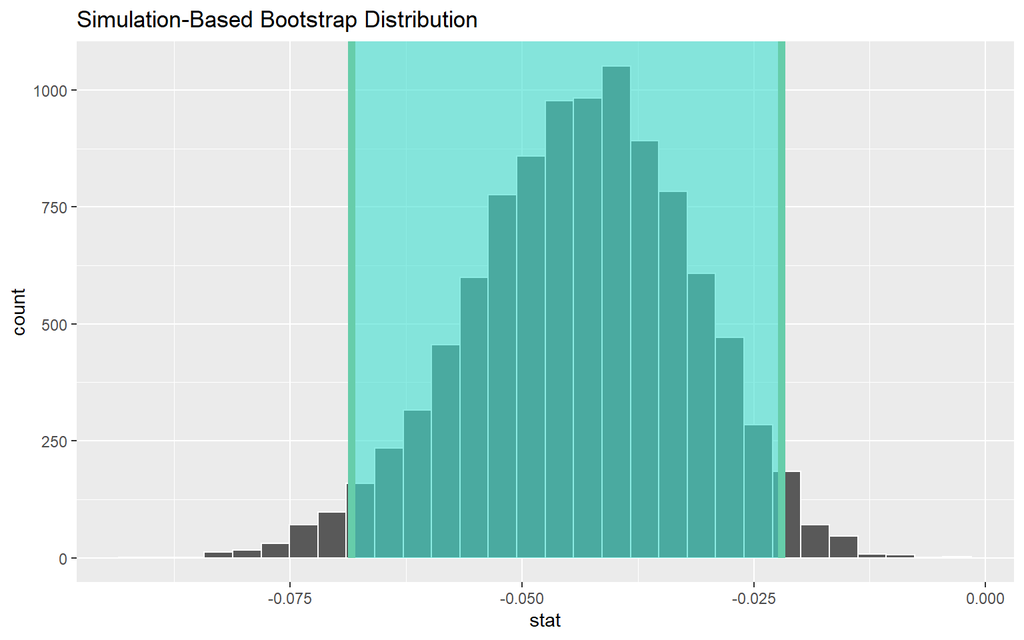

```r
slope_hat_boot_dist %>% visualize(bins = 30) +
  shade_confidence_interval(endpoints = slope_percentile_ci)
```

```r
### For R, the correlation coefficient:

R_hat <-  elmhurst %>%
  specify(gift_aid ~ family_income) %>%
  calculate(stat = "correlation")
R_hat
```

```
## Response: gift_aid (numeric)
## Explanatory: family_income (numeric)
## # A tibble: 1 × 1
##     stat
##    <dbl>
## 1 -0.499
```

```r
R_hat_boot_dist <- elmhurst %>%
  specify(gift_aid ~ family_income) %>%
  generate(reps = 10000, type = "bootstrap") %>%
  calculate(stat = "correlation")

R_percentile_ci <- get_ci(R_hat_boot_dist)
R_percentile_ci
```

```
## # A tibble: 1 × 2
##   lower_ci upper_ci
##      <dbl>    <dbl>
## 1   -0.696   -0.286
```

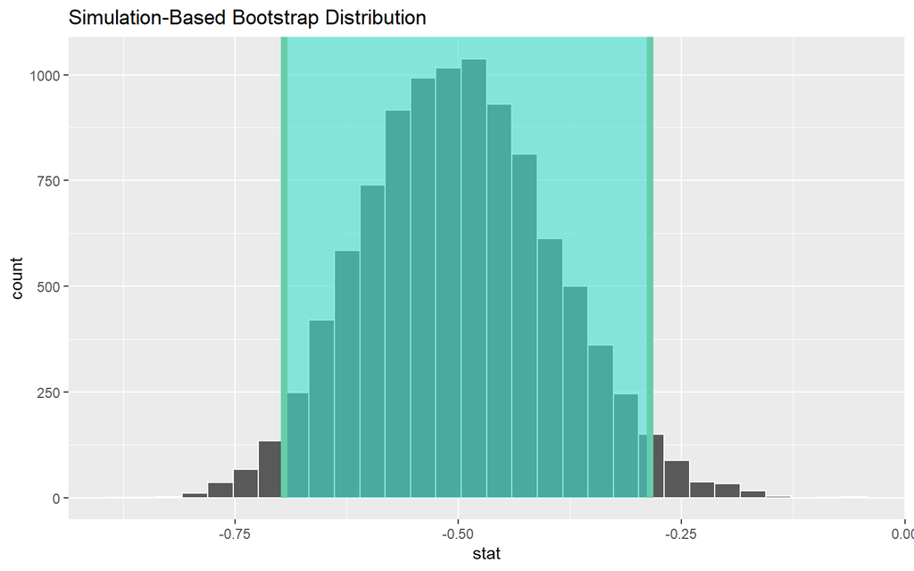

```r
R_hat_boot_dist %>% visualize(bins = 30) +
  shade_confidence_interval(endpoints = R_percentile_ci)
```

We can also run a hypothesis test with null hypothesis that the slope (or R) is equal to 0. As before, we will run a permutation test:

```r
slope_hat <-  elmhurst %>%
  specify(gift_aid ~ family_income) %>%
  calculate(stat = "slope")
slope_hat
```

```
## Response: gift_aid (numeric)
## Explanatory: family_income (numeric)
## # A tibble: 1 × 1
##      stat
##     <dbl>
## 1 -0.0431
```

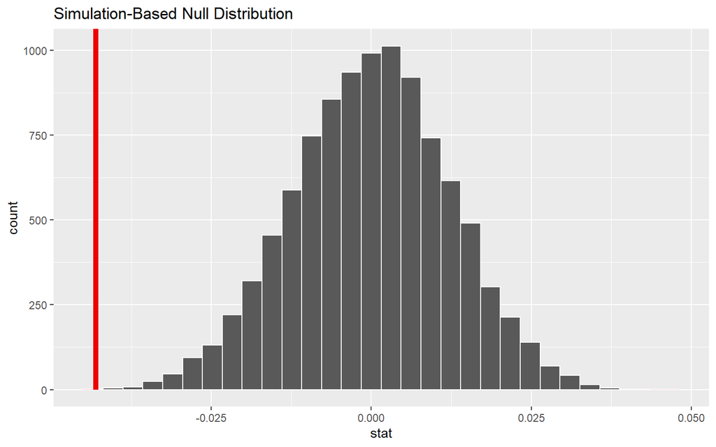

```r
slope_hat_null_dist <- elmhurst %>%
  specify(gift_aid ~ family_income) %>%
  hypothesize(null = "independence") %>%
  generate(reps = 10000, type = "permute") %>%
  calculate(stat = "slope")

slope_hat_null_dist %>% visualize(bins = 30) +
  shade_p_value(obs_stat = slope_hat, direction = "two-sided")
```

```r
slope_hat_p_value <- slope_hat_null_dist %>%
  get_p_value(obs_stat = slope_hat, direction = "two-sided")
slope_hat_p_value
```

```
## # A tibble: 1 × 1
##   p_value
##     <dbl>
## 1  0.0002
```

## Investigate the EPI-Wages-R data set

One way that linear regression is commonly used is in analyzing time series data. **We should be careful:** one of the requirements of linear regression is that the data points are independent of each other. In time series data, successive observations are often related to each other. In practice, we won’t worry about this too much, but it is worth keeping in mind.

Let’s download some data on median and mean wages for different groups over time: Go to https://sustainabilitymath.org/statistics-materials/ and scroll to the bottom; look for “Hourly Wage by Race and Gender.” Download either the Excel or .csv file, either one can be imported into R.

```r
library(readr)
EPI_Wages_R <- read_csv("EPI-Wages-R.csv")  # put the .csv file in
                                            #your working directory first!
```

Let’s start by recreating the headline graphical finding: the gap between median wages of men and women is closing, but still present. We can use the following code:

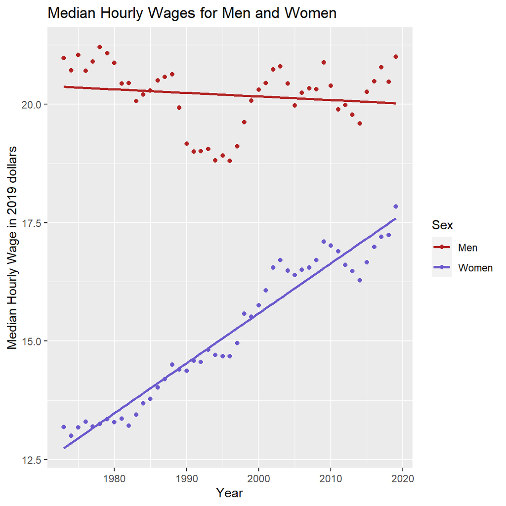

```r
EPI_Wages_R %>% ggplot() +
  geom_point(aes(x = Date, y = `Men Median`, color = "Men")) +
  geom_point(aes(x = Date, y = `Women Median`, color = "Women")) +
  geom_smooth(aes(x = Date, y = `Men Median`, color = "Men"),
              method = lm, se = FALSE) +
  geom_smooth(aes(x = Date, y = `Women Median`, color = "Women"),
              method = lm, se = FALSE) +
  scale_color_manual(breaks = c("Men", "Women"),
                     values = c("firebrick", "slateblue")) +
  labs(title = "Median Hourly Wages for Men and Women",
       x = "Year",
       y = "Median Hourly Wage in 2019 dollars",
       color = "Sex")
```

This code is pretty clunky. We can use the `pivot_longer` function from `tidyr` (one of the `tidyverse` packages):

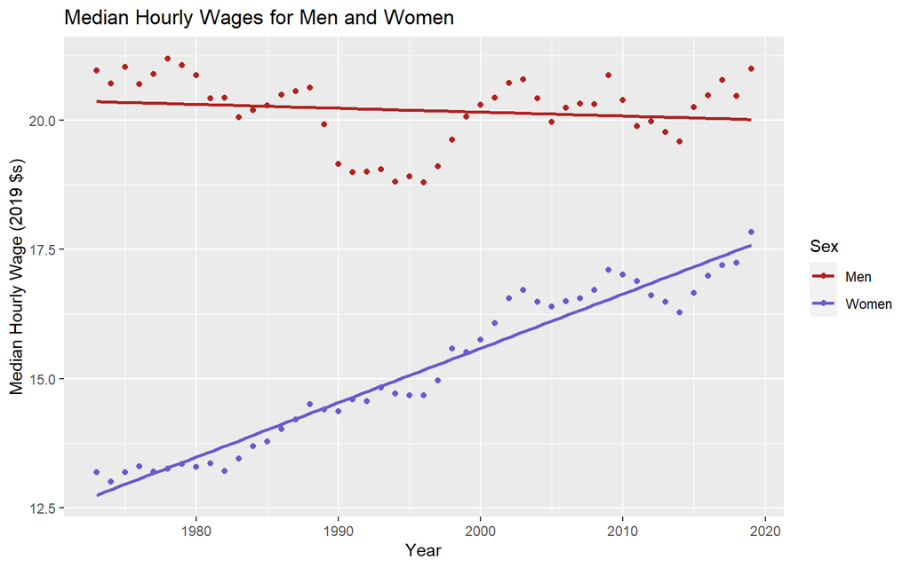

```r
EPI_Wages_tidy <- EPI_Wages_R %>%
  pivot_longer(c(`Men Median`,`Women Median`),
               names_to = c("sex","measure"),
               names_sep = " ",
               values_to = "value") %>%
  select(c(Date, sex, measure, value))

EPI_Wages_tidy %>%
  ggplot(aes(
    x = Date,
    y = value,
    groups = sex,
    col = sex
  )) +
  geom_point() +
  geom_smooth(method = lm, se = F) +
  scale_color_manual(breaks = c("Men", "Women"),
                     values = c("firebrick", "slateblue")) +
  labs(title = "Median Hourly Wages for Men and Women",
       x = "Year",
       y = "Median Hourly Wage (2019 $s)",
       color = "Sex")
```

Let’s find the linear regression models and correlation coefficients:

```r
EPI_Wages_tidy %>%
  filter(sex == "Men") %>%
  lm(value ~ Date, data = .)
```

```
##
## Call:
## lm(formula = value ~ Date, data = .)
##
## Coefficients:
## (Intercept)         Date
##   35.177253    -0.007507
```

```r
EPI_Wages_tidy %>%
  filter(sex == "Men") %>%
  summarize(cor(value, Date))
```

```
## # A tibble: 1 × 1
##   `cor(value, Date)`
##                <dbl>
## 1             -0.154
```

```r
EPI_Wages_tidy %>%
  filter(sex == "Women") %>%
  lm(value ~ Date, data = .)
```

```
##
## Call:
## lm(formula = value ~ Date, data = .)
##
## Coefficients:
## (Intercept)         Date
##   -195.1654       0.1054
```

```r
EPI_Wages_tidy %>%
  filter(sex == "Women") %>%
  summarize(cor(value, Date))
```

```
## # A tibble: 1 × 1
##   `cor(value, Date)`
##                <dbl>
## 1              0.973
```

Before continuing, ask yourself: is it true that men’s median wages are declining? Run a hypothesis test to find out!

What happens if we look at average (mean) wages instead?

## Investigate the Lead and Crime data set

Download Lead-and-Crime.xlsx from https://sustainabilitymath.org/statistics-materials/ (about halfway down the page). When you import it into R, notice that we will want to skip the first 11 lines that contain descriptive information.

According to that information, violent crime follows a 22-year lag: that is, assault corresponds most closely with the gasoline lead additives from 22 years previously.

Let’s start by creating a new columns that accounts for that lag. We have a bit of cleanup to do with `dplyr` functions as well:

```r
library(readxl)
Lead_and_Crime <- read_excel("Lead-and-Crime.xlsx",
     skip = 11)
Lead_and_Crime <- Lead_and_Crime %>%
  rename(
  "year" = 6,
  "population" = 2,
  "lead_added" = 3,
  "lead_per_cap" = 4,
  "violent_crime" = 8,
  "violent_crime_rate" = 9,
  "assault" = 10,
  "assault_rate" = 11,
  "robbery" = 12,
  "robbery_rate" = 13,
  "rape" = 14,
  "rape_rate" = 15,
  "unemp_16_19" = 16,
  "unemp_16_24" = 17,
)
Lead_and_Crime <- Lead_and_Crime %>%
  select(-any_of(c(1,5,7)))
Lead_and_Crime_lags <- Lead_and_Crime %>%
  mutate(
    lead_19yr_lag = lead_per_cap,
    lead_22yr_lag = lag(lead_per_cap, 3),
    lead_24yr_lag = lag(lead_per_cap, 5)
    )
```

Let’s graph violent crime and lead per capita (with a 22-year lag) on the y-axis, and year on the x-axis.

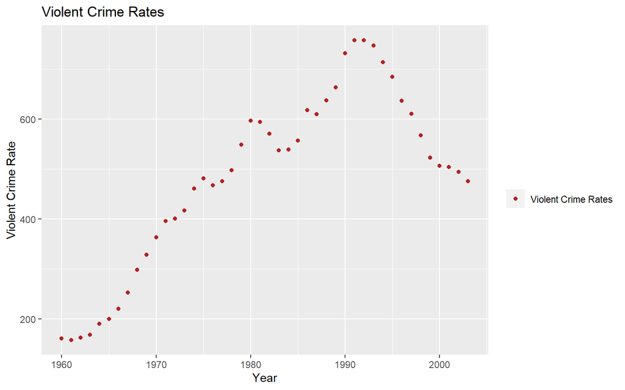

```r
Lead_and_Crime_lags %>% ggplot() +
  geom_point(mapping=aes(x = year,y = violent_crime_rate,
                         color='Violent Crime Rates')) +
  labs(title = "Violent Crime Rates",
       x = "Year",
       y = "Violent Crime Rate") +
  scale_color_manual('',
                breaks = c('Lead (22 years earlier)', 'Violent Crime Rates'),
                values = c('slateblue', 'firebrick'))
```

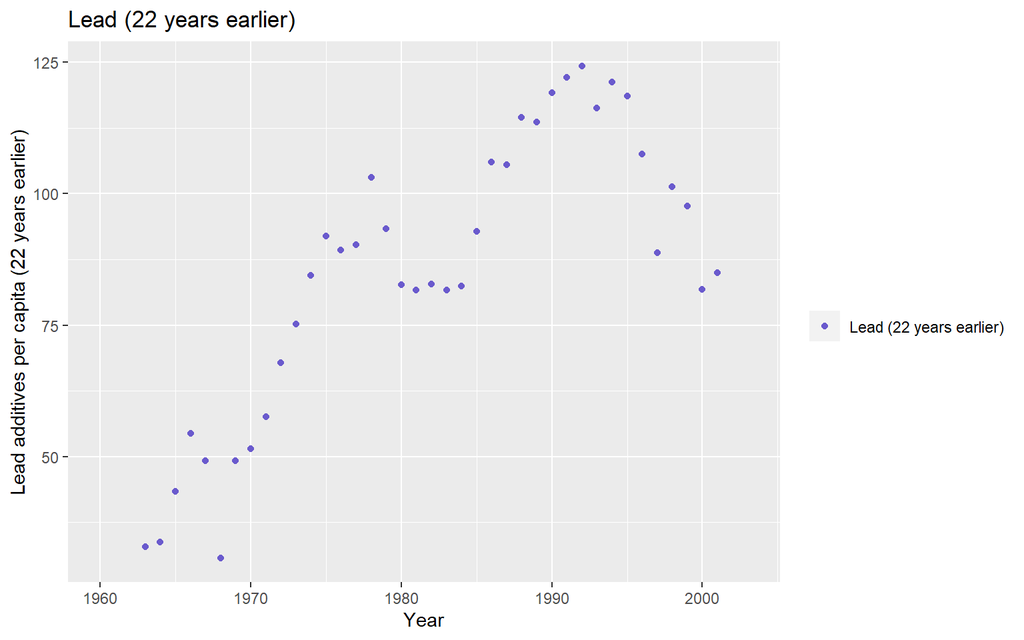

```r
Lead_and_Crime_lags %>% ggplot() +
  geom_point(mapping=aes(x = year, y = lead_22yr_lag,
             color='Lead (22 years earlier)')) +
  labs(title = "Lead (22 years earlier)",
       x = "Year",
       y = "Lead additives per capita (22 years earlier)") +
  scale_color_manual('',
                breaks = c('Lead (22 years earlier)', 'Violent Crime Rates'),
                values = c('slateblue', 'firebrick'))
```

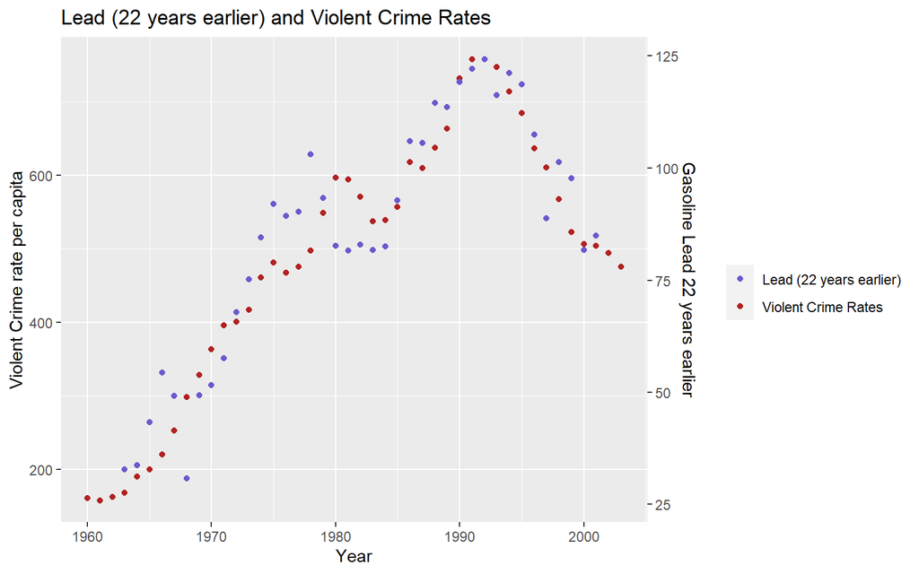

```r
### Scaling factor to place both on the same axes

scale_fac <- Lead_and_Crime_lags %>%
  drop_na(lead_22yr_lag) %>%
  summarize(max(violent_crime_rate) / max(lead_22yr_lag)) %>%
  as.numeric()

### Both graphs overlaid:

Lead_and_Crime_lags %>% ggplot() +
  geom_point(aes(x = year,y = violent_crime_rate,
                         color='Violent Crime Rates'))+
  geom_point(aes(x = year, y = lead_22yr_lag * scale_fac,
             color='Lead (22 years earlier)'))+
  labs(title = "Lead (22 years earlier) and Violent Crime Rates",
       x = "Year")+
  scale_color_manual('',
                breaks = c('Lead (22 years earlier)', 'Violent Crime Rates'),
                values = c('slateblue', 'firebrick')) +
  scale_y_continuous(name = "Violent Crime rate per capita",
  sec.axis = sec_axis(~ . / scale_fac, name="Gasoline Lead 22 years earlier"))
```

Can we plot linear regression lines?

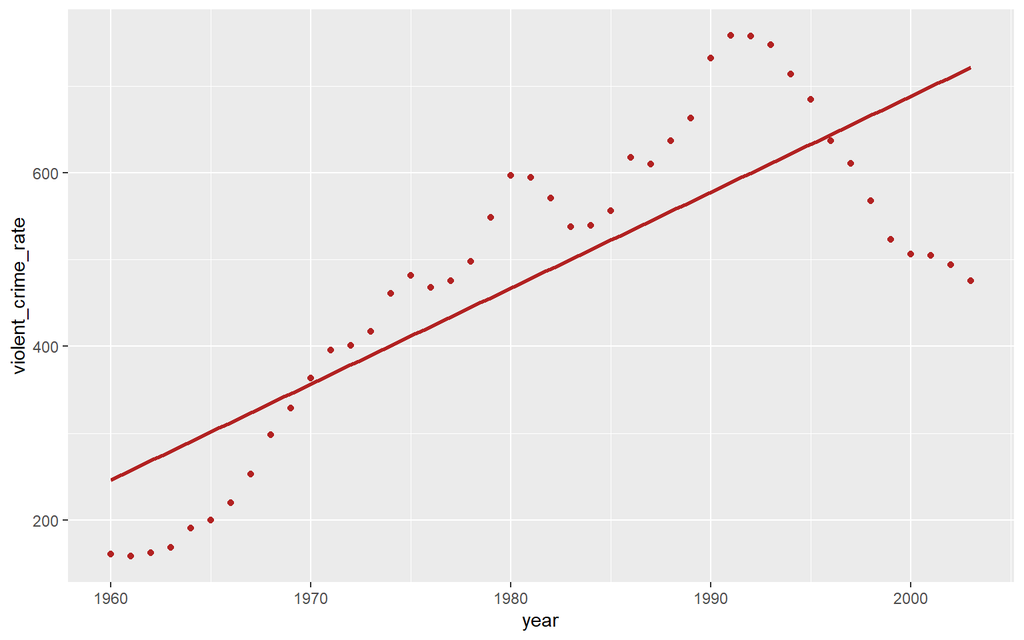

```r
Lead_and_Crime_lags %>% ggplot(aes(x = year,y = violent_crime_rate)) +
  geom_point(color='firebrick') +
  geom_smooth(color='firebrick',
              method = lm, se=FALSE)
```

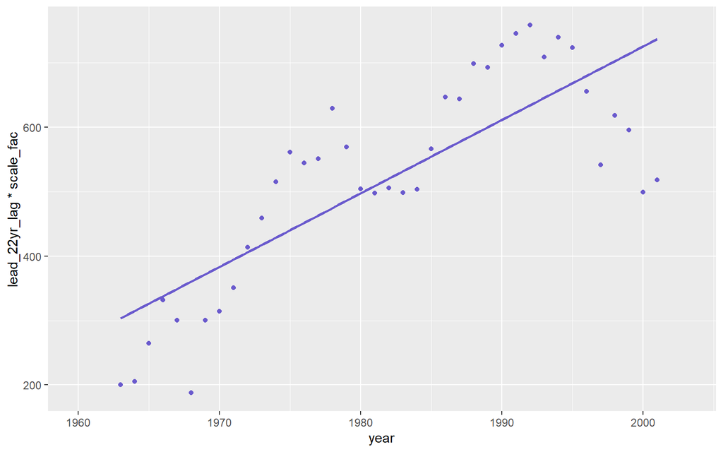

```r
Lead_and_Crime_lags %>%  ggplot(aes(x = year, y = lead_22yr_lag*scale_fac)) +
  geom_point(color='slateblue') +
  geom_smooth(color='slateblue',
      method = lm, se=FALSE)
```

Oh dear, that doesn’t look good at all. There is an obvious peak around 1991-1992, let’s break up our data at that point:

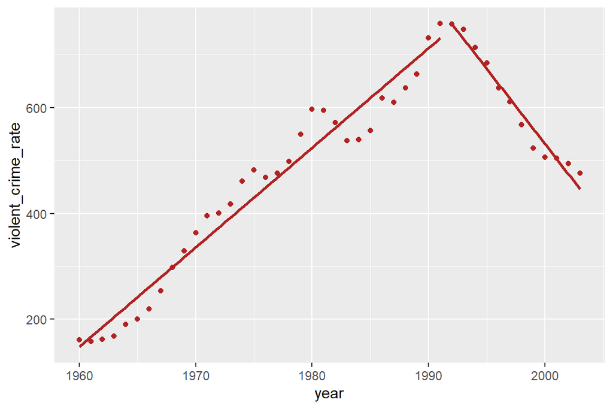

```r
Lead_and_Crime_lags %>% ggplot(aes(x = year,y = violent_crime_rate)) +
  geom_point(color='firebrick') +
  geom_smooth(data = subset(Lead_and_Crime_lags, year <= 1991),
              color='firebrick', method = lm, se = FALSE) +
  geom_smooth(data = subset(Lead_and_Crime_lags, year >= 1992),
              color='firebrick', method = lm, se = FALSE)
```

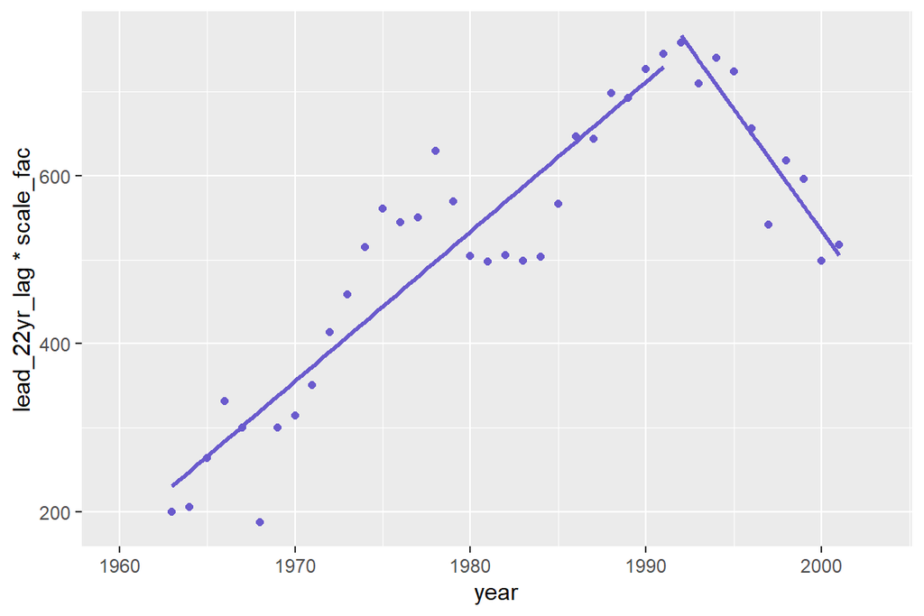

```r
Lead_and_Crime_lags %>%  ggplot(aes(x = year, y = lead_22yr_lag*scale_fac)) +
  geom_point(color='slateblue') +
  geom_smooth(data = subset(Lead_and_Crime_lags, year <= 1991),
              color='slateblue', method = lm, se = FALSE) +
  geom_smooth(data = subset(Lead_and_Crime_lags, year >= 1992),
              color='slateblue', method = lm, se=FALSE)
```

What we really want, however, is to know the relationship between lead and violent crime. Let’s look at the relationship between these directly:

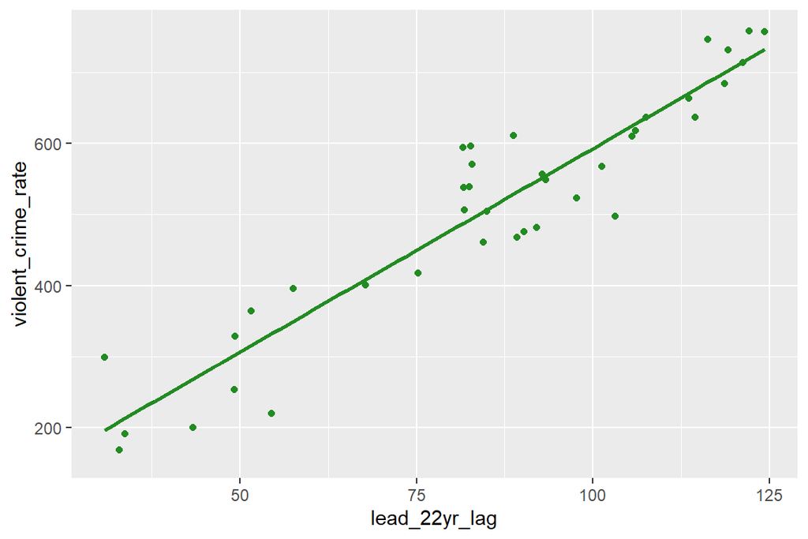

```r
Lead_and_Crime_lags %>% ggplot(aes(x = lead_22yr_lag, y = violent_crime_rate)) +
  geom_point(color='forestgreen') +
  geom_smooth(color='forestgreen', method = lm, se = FALSE)
```

```r
Lead_and_Crime_lags %>%
  lm(violent_crime_rate ~ lead_22yr_lag, data=.) %>%
  summary()
```

```
##
## Call:
## lm(formula = violent_crime_rate ~ lead_22yr_lag, data = .)
##
## Residuals:
##      Min       1Q   Median       3Q      Max
## -113.075  -39.437   -6.049   42.291  106.619
##
## Coefficients:
##               Estimate Std. Error t value            Pr(>|t|)
## (Intercept)    19.6158    30.4459   0.644               0.523
## lead_22yr_lag   5.7338     0.3409  16.818 <0.0000000000000002 ***
## ---
## Signif. codes:  0 '***' 0.001 '**' 0.01 '*' 0.05 '.' 0.1 ' ' 1
##
## Residual standard error: 56.42 on 37 degrees of freedom
##   (5 observations deleted due to missingness)
## Multiple R-squared:  0.8843, Adjusted R-squared:  0.8812
## F-statistic: 282.9 on 1 and 37 DF,  p-value: < 0.00000000000000022
```

```r
Lead_and_Crime_lags %>% summarize(
  cor(violent_crime_rate, lead_22yr_lag, use = 'complete.obs'))
```

```
## # A tibble: 1 × 1
##   `cor(violent_crime_rate, lead_22yr_lag, use = "complete.obs")`
##                                                            <dbl>
## 1                                                          0.940
```

# Linear and Multiple Regression

This section is based on an activity found at (https://openintrostat.github.io/oilabs-tidy/09_multiple_regression/multiple_regression.html)

For the last section, let’s look at a set of data collected from University of Texas at Austin, containing average evaluation scores for 463 courses. In addition, six students rated the physical appearance of each professor. The premise of the study is that better looking teachers are rated more favorably. Let’s look at the data:

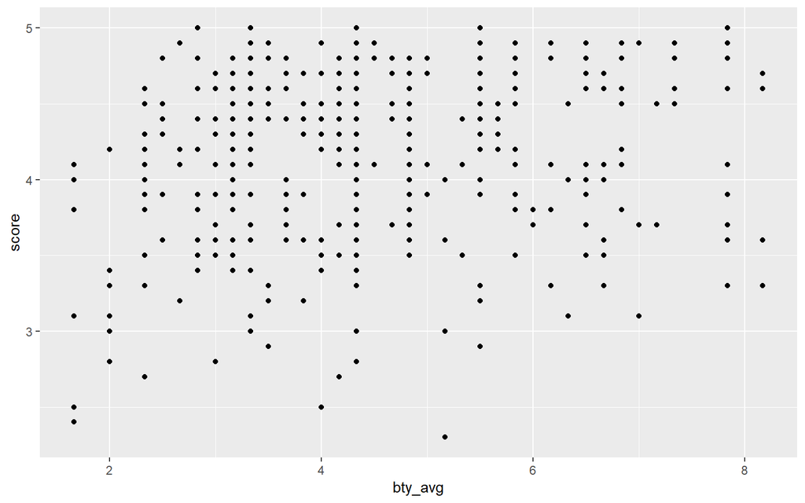

```r
evals %>% ggplot(aes(x = bty_avg, y = score)) +
  geom_point()
```

You may notice that we seem to have fewer points than we should in our scatterplot. Try `geom_jitter` instead of `geom_point`:

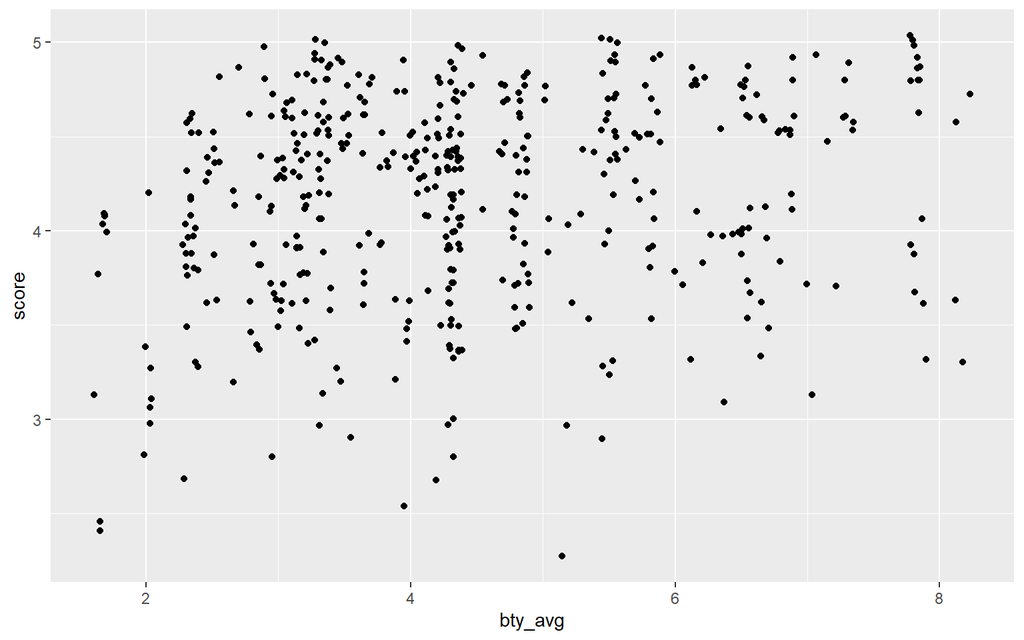

```r
evals %>% ggplot(aes(x = bty_avg, y = score)) +
  geom_jitter()
```

As before, we can plot a regression line:

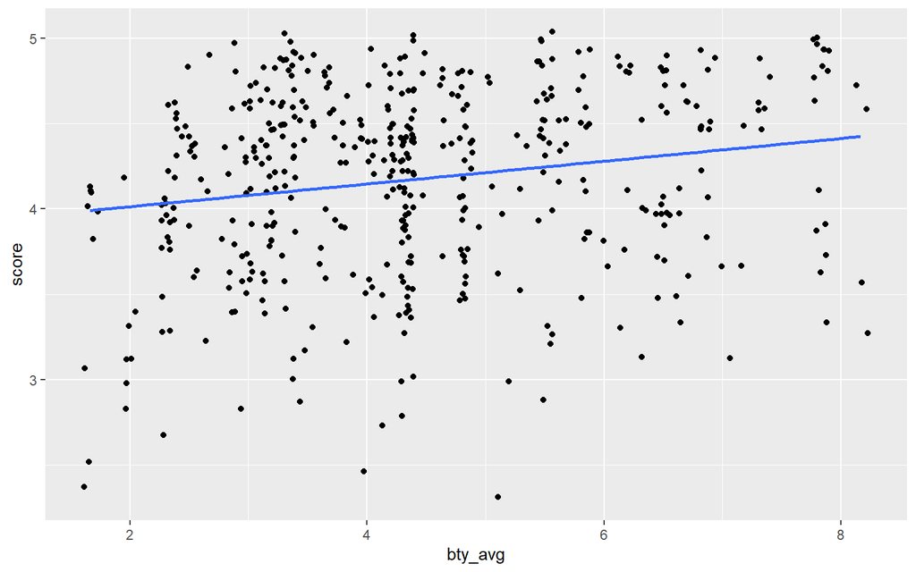

```r
ggplot(data = evals, aes(x = bty_avg, y = score)) +
  geom_jitter() +
  geom_smooth(method = "lm", se = FALSE)
```

```r
model_bty <- evals %>%
  lm(score ~ bty_avg, data = .)
summary(model_bty)
```

```
##
## Call:
## lm(formula = score ~ bty_avg, data = .)
##
## Residuals:
##     Min      1Q  Median      3Q     Max
## -1.9246 -0.3690  0.1420  0.3977  0.9309
##
## Coefficients:
##             Estimate Std. Error t value             Pr(>|t|)
## (Intercept)  3.88034    0.07614   50.96 < 0.0000000000000002 ***
## bty_avg      0.06664    0.01629    4.09            0.0000508 ***
## ---
## Signif. codes:  0 '***' 0.001 '**' 0.01 '*' 0.05 '.' 0.1 ' ' 1
##
## Residual standard error: 0.5348 on 461 degrees of freedom
## Multiple R-squared:  0.03502,    Adjusted R-squared:  0.03293
## F-statistic: 16.73 on 1 and 461 DF,  p-value: 0.00005083
```

Now, we can add more variables into the model. We want to try to add variables that are *independent*, when possible. For example, it wouldn’t make sense to add any of the individual `bty` variables, since they are highly correlated. For example:

```r
evals %>%
  summarise(cor(bty_avg, bty_f1lower))
```

```
## # A tibble: 1 × 1
##   `cor(bty_avg, bty_f1lower)`
##                         <dbl>
## 1                       0.844
```

Let’s see what happens when we add a categorical variable, `gender`, to the model:

```r
model_bty_gen <- lm(score ~ bty_avg + gender, data = evals)
summary(model_bty_gen)
```

```
##
## Call:
## lm(formula = score ~ bty_avg + gender, data = evals)
##
## Residuals:
##     Min      1Q  Median      3Q     Max
## -1.8305 -0.3625  0.1055  0.4213  0.9314
##
## Coefficients:
##             Estimate Std. Error t value             Pr(>|t|)
## (Intercept)  3.74734    0.08466  44.266 < 0.0000000000000002 ***
## bty_avg      0.07416    0.01625   4.563           0.00000648 ***
## gendermale   0.17239    0.05022   3.433             0.000652 ***
## ---
## Signif. codes:  0 '***' 0.001 '**' 0.01 '*' 0.05 '.' 0.1 ' ' 1
##
## Residual standard error: 0.5287 on 460 degrees of freedom
## Multiple R-squared:  0.05912,    Adjusted R-squared:  0.05503
## F-statistic: 14.45 on 2 and 460 DF,  p-value: 0.0000008177
```

We can also start with lots of variables, and drop variables that don’t seem to offer much predictive power:

```r
model_full <- lm(score ~ rank + gender + ethnicity + language + age + bty_avg,
                 data = evals)
summary(model_full)
```

```
##
## Call:
## lm(formula = score ~ rank + gender + ethnicity + language + age +
##     bty_avg, data = evals)
##
## Residuals:
##      Min       1Q   Median       3Q      Max
## -1.82004 -0.37119  0.09519  0.40121  0.93758
##
## Coefficients:
##                        Estimate Std. Error t value             Pr(>|t|)
## (Intercept)            4.220222   0.205999  20.487 < 0.0000000000000002 ***
## ranktenure track      -0.178787   0.083393  -2.144              0.03257 *
## ranktenured           -0.146046   0.062166  -2.349              0.01924 *
## gendermale             0.207356   0.052237   3.970            0.0000837 ***
## ethnicitynot minority  0.064679   0.074372   0.870              0.38494
## languagenon-english   -0.177046   0.109648  -1.615              0.10707
## age                   -0.007584   0.003167  -2.395              0.01703 *
## bty_avg                0.062877   0.016709   3.763              0.00019 ***
## ---
## Signif. codes:  0 '***' 0.001 '**' 0.01 '*' 0.05 '.' 0.1 ' ' 1
##
## Residual standard error: 0.5211 on 455 degrees of freedom
## Multiple R-squared:  0.09591,    Adjusted R-squared:  0.082
## F-statistic: 6.895 on 7 and 455 DF,  p-value: 0.0000000827
```

```r
lm(score ~ gender + ethnicity + language + age + bty_avg,
                 data = evals) %>%
  summary()
```

```
##
## Call:
## lm(formula = score ~ gender + ethnicity + language + age + bty_avg,
##     data = evals)
##
## Residuals:
##     Min      1Q  Median      3Q     Max
## -1.8769 -0.3620  0.1079  0.4071  0.9068
##
## Coefficients:
##                        Estimate Std. Error t value             Pr(>|t|)
## (Intercept)            4.014974   0.174975  22.946 < 0.0000000000000002 ***
## gendermale             0.195974   0.051731   3.788             0.000172 ***
## ethnicitynot minority  0.071772   0.074499   0.963             0.335860
## languagenon-english   -0.221444   0.106876  -2.072             0.038829 *
## age                   -0.005956   0.002709  -2.198             0.028434 *
## bty_avg                0.064717   0.016777   3.858             0.000131 ***
## ---
## Signif. codes:  0 '***' 0.001 '**' 0.01 '*' 0.05 '.' 0.1 ' ' 1
##
## Residual standard error: 0.5238 on 457 degrees of freedom
## Multiple R-squared:  0.08239,    Adjusted R-squared:  0.07235
## F-statistic: 8.206 on 5 and 457 DF,  p-value: 0.0000001954
```

```r
lm(score ~ rank + ethnicity + language + age + bty_avg,
                 data = evals) %>%
  summary()
```

```
##
## Call:
## lm(formula = score ~ rank + ethnicity + language + age + bty_avg,
##     data = evals)
##
## Residuals:
##     Min      1Q  Median      3Q     Max
## -1.9029 -0.3482  0.1216  0.4093  0.9547
##
## Coefficients:
##                       Estimate Std. Error t value             Pr(>|t|)
## (Intercept)            4.22042    0.20931  20.164 < 0.0000000000000002 ***
## ranktenure track      -0.18433    0.08472  -2.176             0.030086 *
## ranktenured           -0.11140    0.06254  -1.781             0.075516 .
## ethnicitynot minority  0.08900    0.07531   1.182             0.237924
## languagenon-english   -0.16009    0.11132  -1.438             0.151105
## age                   -0.00566    0.00318  -1.780             0.075767 .
## bty_avg                0.05996    0.01696   3.535             0.000449 ***
## ---
## Signif. codes:  0 '***' 0.001 '**' 0.01 '*' 0.05 '.' 0.1 ' ' 1
##
## Residual standard error: 0.5295 on 456 degrees of freedom
## Multiple R-squared:  0.0646, Adjusted R-squared:  0.05229
## F-statistic: 5.248 on 6 and 456 DF,  p-value: 0.00003044
```

```r
lm(score ~ rank + gender + language + age + bty_avg,
                 data = evals) %>%
  summary()
```

```
##
## Call:
## lm(formula = score ~ rank + gender + language + age + bty_avg,
##     data = evals)
##
## Residuals:
##      Min       1Q   Median       3Q      Max
## -1.80602 -0.36495  0.09837  0.40369  0.94605
##
## Coefficients:
##                      Estimate Std. Error t value             Pr(>|t|)
## (Intercept)          4.274171   0.196385  21.764 < 0.0000000000000002 ***
## ranktenure track    -0.184077   0.083149  -2.214              0.02733 *
## ranktenured         -0.146057   0.062149  -2.350              0.01919 *
## gendermale           0.211098   0.052045   4.056            0.0000587 ***
## languagenon-english -0.202271   0.105714  -1.913              0.05633 .
## age                 -0.007533   0.003166  -2.380              0.01774 *
## bty_avg              0.062859   0.016705   3.763              0.00019 ***
## ---
## Signif. codes:  0 '***' 0.001 '**' 0.01 '*' 0.05 '.' 0.1 ' ' 1
##
## Residual standard error: 0.521 on 456 degrees of freedom
## Multiple R-squared:  0.0944, Adjusted R-squared:  0.08249
## F-statistic: 7.923 on 6 and 456 DF,  p-value: 0.00000003872
```

```r
lm(score ~ rank + gender + ethnicity + age + bty_avg,
                 data = evals) %>%
  summary()
```

```
##
## Call:
## lm(formula = score ~ rank + gender + ethnicity + age + bty_avg,
##     data = evals)
##
## Residuals:
##      Min       1Q   Median       3Q      Max
## -1.79959 -0.36672  0.08821  0.40758  0.93547
##
## Coefficients:
##                        Estimate Std. Error t value             Pr(>|t|)
## (Intercept)            4.231693   0.206239  20.518 < 0.0000000000000002 ***
## ranktenure track      -0.210460   0.081196  -2.592             0.009848 **
## ranktenured           -0.151837   0.062172  -2.442             0.014976 *
## gendermale             0.204070   0.052289   3.903             0.000109 ***
## ethnicitynot minority  0.096445   0.071849   1.342             0.180157
## age                   -0.008315   0.003140  -2.648             0.008376 **
## bty_avg                0.062478   0.016737   3.733             0.000213 ***
## ---
## Signif. codes:  0 '***' 0.001 '**' 0.01 '*' 0.05 '.' 0.1 ' ' 1
##
## Residual standard error: 0.522 on 456 degrees of freedom
## Multiple R-squared:  0.09073,    Adjusted R-squared:  0.07876
## F-statistic: 7.583 on 6 and 456 DF,  p-value: 0.00000009044
```

```r
lm(score ~ rank + gender + ethnicity + language + bty_avg,
                 data = evals) %>%
  summary()
```

```
##
## Call:
## lm(formula = score ~ rank + gender + ethnicity + language + bty_avg,
##     data = evals)
##
## Residuals:
##      Min       1Q   Median       3Q      Max
## -1.85411 -0.35386  0.09867  0.39574  0.96617
##
## Coefficients:
##                       Estimate Std. Error t value             Pr(>|t|)
## (Intercept)            3.81061    0.11540  33.020 < 0.0000000000000002 ***
## ranktenure track      -0.09106    0.07530  -1.209             0.227211
## ranktenured           -0.15110    0.06245  -2.419             0.015933 *
## gendermale             0.18821    0.05189   3.627             0.000319 ***
## ethnicitynot minority  0.06138    0.07474   0.821             0.411962
## languagenon-english   -0.21456    0.10909  -1.967             0.049796 *
## bty_avg                0.07222    0.01633   4.422            0.0000122 ***
## ---
## Signif. codes:  0 '***' 0.001 '**' 0.01 '*' 0.05 '.' 0.1 ' ' 1
##
## Residual standard error: 0.5238 on 456 degrees of freedom
## Multiple R-squared:  0.08451,    Adjusted R-squared:  0.07247
## F-statistic: 7.016 on 6 and 456 DF,  p-value: 0.0000003735
```

```r
lm(score ~ rank + gender + ethnicity + language + age,
                 data = evals) %>%
  summary()
```

```
##
## Call:
## lm(formula = score ~ rank + gender + ethnicity + language + age,
##     data = evals)
##
## Residuals:
##     Min      1Q  Median      3Q     Max
## -1.7994 -0.3599  0.0846  0.4127  0.9721
##
## Coefficients:
##                        Estimate Std. Error t value             Pr(>|t|)
## (Intercept)            4.645281   0.174736  26.585 < 0.0000000000000002 ***
## ranktenure track      -0.185164   0.084571  -2.189             0.029070 *
## ranktenured           -0.157507   0.062981  -2.501             0.012738 *
## gendermale             0.198719   0.052934   3.754             0.000196 ***
## ethnicitynot minority  0.064336   0.075437   0.853             0.394194
## languagenon-english   -0.170950   0.111207  -1.537             0.124933
## age                   -0.010367   0.003124  -3.319             0.000976 ***
## ---
## Signif. codes:  0 '***' 0.001 '**' 0.01 '*' 0.05 '.' 0.1 ' ' 1
##
## Residual standard error: 0.5286 on 456 degrees of freedom
## Multiple R-squared:  0.06777,    Adjusted R-squared:  0.0555
## F-statistic: 5.525 on 6 and 456 DF,  p-value: 0.00001534
```

```r
model_2 <- lm(score ~ rank + gender + language + age + bty_avg,
                 data = evals)
summary(model_2)
```

```
##
## Call:
## lm(formula = score ~ rank + gender + language + age + bty_avg,
##     data = evals)
##
## Residuals:
##      Min       1Q   Median       3Q      Max
## -1.80602 -0.36495  0.09837  0.40369  0.94605
##
## Coefficients:
##                      Estimate Std. Error t value             Pr(>|t|)
## (Intercept)          4.274171   0.196385  21.764 < 0.0000000000000002 ***
## ranktenure track    -0.184077   0.083149  -2.214              0.02733 *
## ranktenured         -0.146057   0.062149  -2.350              0.01919 *
## gendermale           0.211098   0.052045   4.056            0.0000587 ***
## languagenon-english -0.202271   0.105714  -1.913              0.05633 .
## age                 -0.007533   0.003166  -2.380              0.01774 *
## bty_avg              0.062859   0.016705   3.763              0.00019 ***
## ---
## Signif. codes:  0 '***' 0.001 '**' 0.01 '*' 0.05 '.' 0.1 ' ' 1
##
## Residual standard error: 0.521 on 456 degrees of freedom
## Multiple R-squared:  0.0944, Adjusted R-squared:  0.08249
## F-statistic: 7.923 on 6 and 456 DF,  p-value: 0.00000003872
```

```r
lm(score ~ gender + language + age + bty_avg,
                 data = evals) %>%
  summary()
```

```
##
## Call:
## lm(formula = score ~ gender + language + age + bty_avg, data = evals)
##
## Residuals:
##     Min      1Q  Median      3Q     Max
## -1.8648 -0.3538  0.1154  0.4105  0.9180
##
## Coefficients:
##                      Estimate Std. Error t value             Pr(>|t|)
## (Intercept)          4.066822   0.166480  24.428 < 0.0000000000000002 ***
## gendermale           0.200574   0.051507   3.894             0.000113 ***
## languagenon-english -0.251754   0.102133  -2.465             0.014069 *
## age                 -0.005764   0.002702  -2.133             0.033432 *
## bty_avg              0.064691   0.016775   3.856             0.000132 ***
## ---
## Signif. codes:  0 '***' 0.001 '**' 0.01 '*' 0.05 '.' 0.1 ' ' 1
##
## Residual standard error: 0.5238 on 458 degrees of freedom
## Multiple R-squared:  0.08052,    Adjusted R-squared:  0.07249
## F-statistic: 10.03 on 4 and 458 DF,  p-value: 0.000000087
```

```r
lm(score ~ rank + language + age + bty_avg,
                 data = evals) %>%
  summary()
```

```
##
## Call:
## lm(formula = score ~ rank + language + age + bty_avg, data = evals)
##
## Residuals:
##     Min      1Q  Median      3Q     Max
## -1.8855 -0.3400  0.1237  0.4153  0.9616
##
## Coefficients:
##                      Estimate Std. Error t value             Pr(>|t|)
## (Intercept)          4.295166   0.199608  21.518 < 0.0000000000000002 ***
## ranktenure track    -0.191798   0.084521  -2.269             0.023719 *
## ranktenured         -0.110554   0.062561  -1.767             0.077875 .
## languagenon-english -0.194611   0.107469  -1.811             0.070821 .
## age                 -0.005541   0.003180  -1.743             0.082075 .
## bty_avg              0.059865   0.016968   3.528             0.000461 ***
## ---
## Signif. codes:  0 '***' 0.001 '**' 0.01 '*' 0.05 '.' 0.1 ' ' 1
##
## Residual standard error: 0.5297 on 457 degrees of freedom
## Multiple R-squared:  0.06173,    Adjusted R-squared:  0.05147
## F-statistic: 6.014 on 5 and 457 DF,  p-value: 0.00002104
```

```r
lm(score ~ rank + gender + age + bty_avg,
                 data = evals) %>%
  summary()
```

```
##
## Call:
## lm(formula = score ~ rank + gender + age + bty_avg, data = evals)
##
## Residuals:
##      Min       1Q   Median       3Q      Max
## -1.77244 -0.36470  0.09613  0.41725  0.94857
##
## Coefficients:
##                   Estimate Std. Error t value             Pr(>|t|)
## (Intercept)       4.320812   0.195432  22.109 < 0.0000000000000002 ***
## ranktenure track -0.226178   0.080418  -2.813             0.005127 **
## ranktenured      -0.153178   0.062218  -2.462             0.014187 *
## gendermale        0.209319   0.052188   4.011            0.0000707 ***
## age              -0.008400   0.003142  -2.673             0.007779 **
## bty_avg           0.062359   0.016751   3.723             0.000222 ***
## ---
## Signif. codes:  0 '***' 0.001 '**' 0.01 '*' 0.05 '.' 0.1 ' ' 1
##
## Residual standard error: 0.5225 on 457 degrees of freedom
## Multiple R-squared:  0.08713,    Adjusted R-squared:  0.07715
## F-statistic: 8.724 on 5 and 457 DF,  p-value: 0.00000006471
```

```r
lm(score ~ rank + gender + language + bty_avg,
                 data = evals) %>%
  summary()
```

```
##
## Call:
## lm(formula = score ~ rank + gender + language + bty_avg, data = evals)
##
## Residuals:
##     Min      1Q  Median      3Q     Max
## -1.8406 -0.3514  0.1071  0.3981  0.9740
##
## Coefficients:
##                     Estimate Std. Error t value             Pr(>|t|)
## (Intercept)          3.86444    0.09494  40.703 < 0.0000000000000002 ***
## ranktenure track    -0.09664    0.07497  -1.289              0.19803
## ranktenured         -0.15108    0.06243  -2.420              0.01591 *
## gendermale           0.19188    0.05168   3.713              0.00023 ***
## languagenon-english -0.23827    0.10516  -2.266              0.02393 *
## bty_avg              0.07215    0.01633   4.419            0.0000124 ***
## ---
## Signif. codes:  0 '***' 0.001 '**' 0.01 '*' 0.05 '.' 0.1 ' ' 1
##
## Residual standard error: 0.5236 on 457 degrees of freedom
## Multiple R-squared:  0.08316,    Adjusted R-squared:  0.07313
## F-statistic:  8.29 on 5 and 457 DF,  p-value: 0.0000001634
```

```r
lm(score ~ rank + gender + language + age,
                 data = evals) %>%
  summary()
```

```
##
## Call:
## lm(formula = score ~ rank + gender + language + age, data = evals)
##
## Residuals:
##      Min       1Q   Median       3Q      Max
## -1.78545 -0.36065  0.09318  0.41392  0.93322
##
## Coefficients:
##                      Estimate Std. Error t value             Pr(>|t|)
## (Intercept)          4.698824   0.163019  28.824 < 0.0000000000000002 ***
## ranktenure track    -0.190424   0.084320  -2.258             0.024395 *
## ranktenured         -0.157515   0.062962  -2.502             0.012707 *
## gendermale           0.202444   0.052738   3.839             0.000141 ***
## languagenon-english -0.196042   0.107212  -1.829             0.068119 .
## age                 -0.010316   0.003122  -3.304             0.001027 **
## ---
## Signif. codes:  0 '***' 0.001 '**' 0.01 '*' 0.05 '.' 0.1 ' ' 1
##
## Residual standard error: 0.5284 on 457 degrees of freedom
## Multiple R-squared:  0.06628,    Adjusted R-squared:  0.05607
## F-statistic: 6.488 on 5 and 457 DF,  p-value: 0.000007653
```

```r
model_3 <- lm(score ~ rank + gender + age + bty_avg,
                 data = evals)
summary(model_3)
```

```
##
## Call:
## lm(formula = score ~ rank + gender + age + bty_avg, data = evals)
##
## Residuals:
##      Min       1Q   Median       3Q      Max
## -1.77244 -0.36470  0.09613  0.41725  0.94857
##
## Coefficients:
##                   Estimate Std. Error t value             Pr(>|t|)
## (Intercept)       4.320812   0.195432  22.109 < 0.0000000000000002 ***
## ranktenure track -0.226178   0.080418  -2.813             0.005127 **
## ranktenured      -0.153178   0.062218  -2.462             0.014187 *
## gendermale        0.209319   0.052188   4.011            0.0000707 ***
## age              -0.008400   0.003142  -2.673             0.007779 **
## bty_avg           0.062359   0.016751   3.723             0.000222 ***
## ---
## Signif. codes:  0 '***' 0.001 '**' 0.01 '*' 0.05 '.' 0.1 ' ' 1
##
## Residual standard error: 0.5225 on 457 degrees of freedom
## Multiple R-squared:  0.08713,    Adjusted R-squared:  0.07715
## F-statistic: 8.724 on 5 and 457 DF,  p-value: 0.00000006471
```

What does this model tell us?